# CREEM Social Media Analysis R code

# CREEM Social Media Analysis R code

```r
library(tidyverse)
library(dplyr)
library(lubridate)
```

### How has our following grown since 2019?

Using data scraped from Twitter Analytics, we can build a time series of how we have built a community on twitter. Observing the followers manually, it is likely that the majority is not students of st Andrews or other universities but mostly researchers and academics following CREEM research.

This data is only accessible for the CREEM_cake account, hence incomparable with our peers.

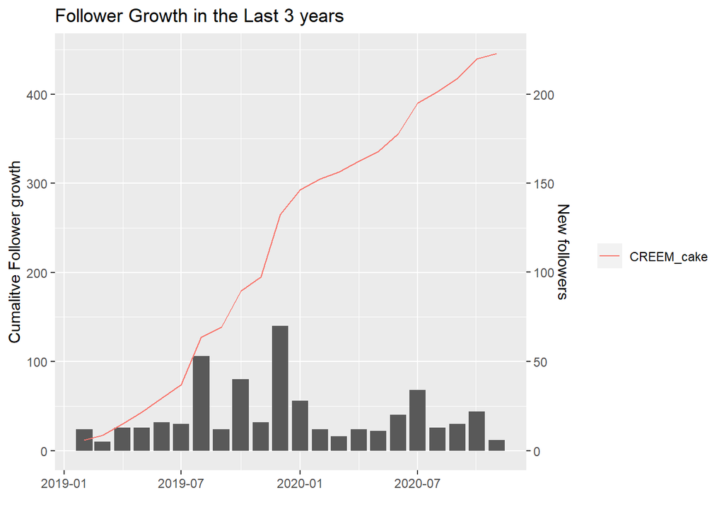

```r
profile_ts <- read.csv('data/creem_data.csv',col.names = c('date','New.followers')) %>%
  # rename(date = ï..date) %>%
  mutate(date = as.Date(date)) %>%
  filter(date > as.Date('2019-01-01'))

# head(profile_ts)
coeff <- 0.5
g <- ggplot(profile_ts,
            aes(x = date, y = New.followers/coeff))

g + geom_col() +
  labs(title = "Follower Growth in the Last 3 years",
       x="") +
  geom_line(aes(x = date, y = cumsum(New.followers),
                color = 'CREEM_cake'
                )) +
   scale_y_continuous(
    # Features of the first axis
    name = "Cumalitve Follower growth",
    # Add a second axis and specify its features
    sec.axis = sec_axis(~.*coeff, name="New followers")
  ) +
  theme(legend.title=element_blank())
```

```r
# legend.position=”none”
# plot(x = profile_ts$date,y = profile_ts$New.followers)==
```

Why was there a spike in followers? ### How often have we been posting in this period?

```r
#loading the data Scraped from SNScrape
tweets <-  read.csv('data/tweet_data.csv') %>%
                mutate(dt= ymd_hms(Datetime),
                       Tweet.Id = as.character(Tweet.Id),
                       year_month = floor_date(as.Date(Datetime),
                                               unit = "month"),
                       year_week = floor_date(as.Date(Datetime),
                                               unit = "week"),
                       time = format(Datetime, format = "%H:%M:%S"),
                       #round time to nearest qtr
                       time_30 = format(round_date(dt, "30 minutes"),
                                        format = "%H:%M:%S"),

                       #remove open close brackets
                       hashtags = gsub("\\[|\\]|\\'","",hashtags)
                       )
summary(tweets)
```

```
##        X           Datetime           Tweet.Id           content
##  Min.   :    0   Length:14181       Length:14181       Length:14181
##  1st Qu.: 3545   Class :character   Class :character   Class :character
##  Median : 7090   Mode  :character   Mode  :character   Mode  :character
##  Mean   : 7090
##  3rd Qu.:10635
##  Max.   :14180
##    Username             url            renderedContent       media
##  Length:14181       Length:14181       Length:14181       Length:14181
##  Class :character   Class :character   Class :character   Class :character
##  Mode  :character   Mode  :character   Mode  :character   Mode  :character
##
##
##
##    likeCount         replyCount      retweetCount       hashtags
##  Min.   :   0.00   Min.   : 0.000   Min.   :  0.000   Length:14181
##  1st Qu.:   1.00   1st Qu.: 0.000   1st Qu.:  0.000   Class :character
##  Median :   4.00   Median : 0.000   Median :  2.000   Mode  :character
##  Mean   :  10.99   Mean   : 0.375   Mean   :  4.962
##  3rd Qu.:  11.00   3rd Qu.: 1.000   3rd Qu.:  6.000
##  Max.   :1840.00   Max.   :52.000   Max.   :885.000
##        dt                        year_month           year_week
##  Min.   :2019-05-01 07:00:57   Min.   :2019-05-01   Min.   :2019-04-28
##  1st Qu.:2019-12-14 12:02:41   1st Qu.:2019-12-01   1st Qu.:2019-12-08
##  Median :2020-09-18 07:42:20   Median :2020-09-01   Median :2020-09-13
##  Mean   :2020-09-25 11:41:18   Mean   :2020-09-10   Mean   :2020-09-21
##  3rd Qu.:2021-05-27 14:15:13   3rd Qu.:2021-05-01   3rd Qu.:2021-05-23
##  Max.   :2022-05-23 09:02:36   Max.   :2022-05-01   Max.   :2022-05-22
##      time             time_30
##  Length:14181       Length:14181
##  Class :character   Class :character
##  Mode  :character   Mode  :character
##
##
##
```

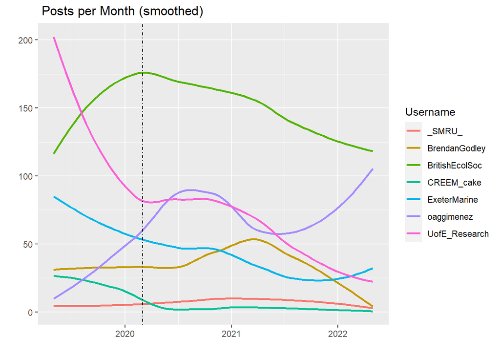

```r
monthly_posts <- tweets %>% group_by(Username) %>% count(year_month)
weekly_posts <- tweets %>% group_by(Username) %>% count(year_week)

follower_ts <- ggplot(monthly_posts,aes(x = year_month, y = n , group = Username,
                        color = Username))
follower_ts +
  geom_smooth(se = F) +
  # geom_point()+
  labs(title = " Posts per Month (smoothed)", y = "", x = "") +
  geom_vline(xintercept = as.numeric(as.Date("2020-03-01")),
                                      linetype=4, colour="black")
```

### Taking a closer look at the CREEM_cake account

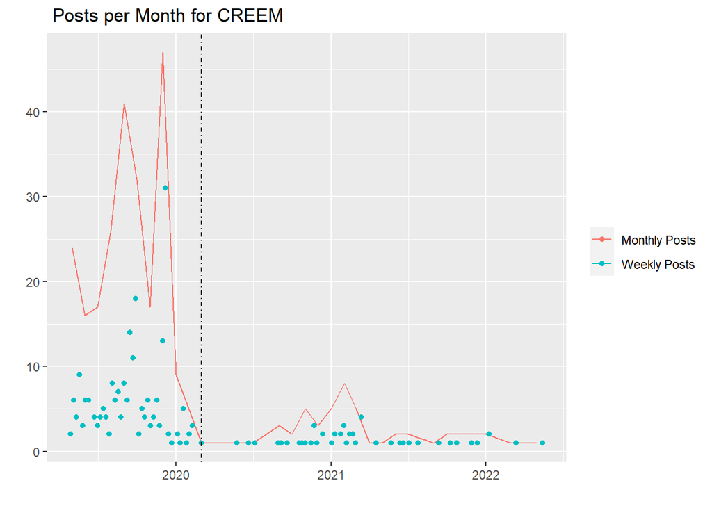

```r
creem_ts <- ggplot(monthly_posts %>% filter(Username == "CREEM_cake"),
                   aes(x = year_month, y = n , group = Username,
                       color = 'Monthly Posts'))  +
  geom_line()
creem_ts  +
  geom_point(data = weekly_posts %>% filter(Username == "CREEM_cake"),
             aes(x = year_week, y = n, color = "Weekly Posts" )) +
  labs(title = " Posts per Month for CREEM", y = "", x= "") +
  #line marking beginning of WFH
  geom_vline(xintercept = as.numeric(as.Date("2020-03-01")),
                                      linetype=4, colour="black")+
theme(legend.title=element_blank())
```

### Does posting more increase follower count?

Assuming a poisson error model, we construct a GLM to model the relationship between how often we post and how many new followers we get.

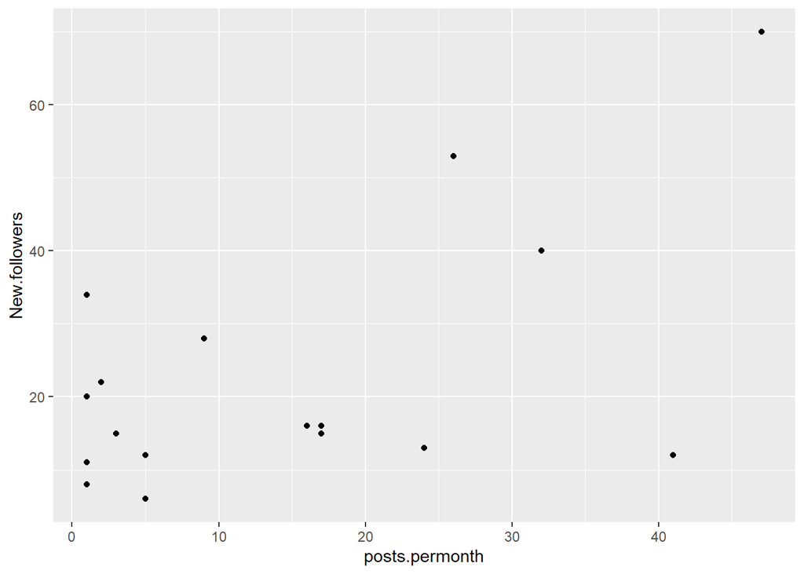

```r
creem_monthly <- monthly_posts %>% #because follower data is monthly
  mutate(date = year_month) %>%
  filter(Username == "CREEM_cake")

#join both datasets
merged_df <- merge(creem_monthly, profile_ts, by = "date") %>%
  rename(posts.permonth = n)

merged_df%>%
  ggplot(aes(x = posts.permonth, y = New.followers)) + geom_point()
```

```r
#glm?
```

```r
follower.fit <- glm(New.followers ~ posts.permonth, data = merged_df, family = "poisson")
# anova(follower.fit, test = 'Chisq')
summary(follower.fit)
```

```
##
## Call:
## glm(formula = New.followers ~ posts.permonth, family = "poisson",
##     data = merged_df)
##
## Deviance Residuals:
##    Min      1Q  Median      3Q     Max
## -5.422  -1.730  -1.131   1.531   4.143
##
## Coefficients:
##                Estimate Std. Error z value Pr(>|z|)
## (Intercept)    2.695492   0.081880  32.920  < 2e-16 ***
## posts.permonth 0.025199   0.003132   8.046 8.59e-16 ***
## ---
## Signif. codes:  0 '***' 0.001 '**' 0.01 '*' 0.05 '.' 0.1 ' ' 1
##
## (Dispersion parameter for poisson family taken to be 1)
##
##     Null deviance: 174.44  on 16  degrees of freedom
## Residual deviance: 113.38  on 15  degrees of freedom
## AIC: 198.42
##
## Number of Fisher Scoring iterations: 5
```

## What content have we been posting up to now?

What has worked in the past can be useful to understand what works for our audience. And it helps to take inspiration from others.

### What do people like?

Looking at the actual text content of the top 10 most liked posts on the CREEM account, we broadly identify the following trends/categories,

- Hiring!
- Congratulations on a hire or a paper
- Paper Alerts

```r
creem_tweets <-  tweets %>% filter(Username == "CREEM_cake")

head(creem_tweets %>% arrange(desc(likeCount)) %>% select(renderedContent, likeCount,url),
     10)
```

|  | renderedContent | likeCount | url |
| --- | --- | --- | --- |
| 1 | Weâ\200\231re hiring! Come work with a sensational team @len_thom @Catriona_StAnd &amp; Peter Tyack @_SMRU_ to build new #rstats methods for understanding the cumulative impacts of human stressors on … | 92 | https://twitter.com/CREEM_cake/status/1280582366784864256 |
| 2 | Excited that @theoni_p started 4-year post with @len_thom, @Catriona_StAnd (@CREEM_cake) and Peter Tyack (@_smru_ ) on a project funded by US ONR and SERDP to understand the cumulative effects of mult… | 81 | https://twitter.com/CREEM_cake/status/1319538144669241344 |
| 3 | Missed Prof. @david_borchers talk on #wildlife population assessment in the #digital age? Fear not! You can catch the replay here bit.ly/2Tz5x2J #rstats #drones #cameras @statsStAndrews @univofstandre… | 71 | https://twitter.com/CREEM_cake/status/1321732923926654977 |
| 4 | Lion cake fr @david_borchers - weâ\200\231re celebrating getting approval to launch a new MSc in Statistical Ecology - watch this space for more info! https://t.co/BEs7q3G8fl | 63 | https://twitter.com/CREEM_cake/status/1177538875402727426 |
| 5 | There is a new doctor in CREEM - our own Claudia defended successfully her PhD thesis last week. As a true CREEMinal, she brought various treats to celebrate this occasion. https://t.co/QnmH9JdYSE | 61 | https://twitter.com/CREEM_cake/status/1226833456467935233 |
| 6 | Congratulations to @dvharris1 and @CSOedekoven for being promoted to grade Senior Research Fellow - celebrating today at CREEM... https://t.co/US8z2mOKk6 | 51 | https://twitter.com/CREEM_cake/status/1146779217436262400 |
| 7 | CREEMcake is back! https://t.co/Hb2u3qQfAU | 49 | https://twitter.com/CREEM_cake/status/1466421176855633946 |
| 8 | Only 5 more sleeps til @CREEM_cake heads to #Barcelona for the world's biggest #marine mammal conference! Don't miss out on the latest #CREEM science Check out this snapshot of our talks and posters! … | 49 | https://twitter.com/CREEM_cake/status/1201176631865425923 |
| 9 | PAPER ALERT: dsmextra - our new #rstats package for assessing extrapolation in ecological #models - is in the latest @MethodsEcolEvol. Comes w step-by-step examples on #dolphins and #whales, crafted b… | 44 | https://twitter.com/CREEM_cake/status/1308686378197225472 |
| 10 | New #paper: Fast, flexible alternatives to regular grid designs for #spatial captureâ\200\220recapture now out in @MethodsEcolEvol - @indurbach @david_borchers @chrissuthy and @koustubh_sharma demonst… | 39 | https://twitter.com/CREEM_cake/status/1323555886309249025 |

### What spreads the word? In terms of retweets

```r
head( creem_tweets %>% arrange(desc(retweetCount)) %>%
       select(content, retweetCount,url),
     10)
```

|  | content | retweetCount | url |
| --- | --- | --- | --- |
| 1 | Weâ\200\231re hiring! Come work with a sensational team @len_thom @Catriona_StAnd &amp; Peter Tyack @_SMRU_ to build new #rstats methods for understanding the cumulative impacts of human stressors on … | 86 | https://twitter.com/CREEM_cake/status/1280582366784864256 |
| 2 | Come work with us! We are looking to hire a #stats consultant for 2 yrs to support applied #research projects and respond to funding opportunities, in a shared post between us &amp; the fabulous folks… | 40 | https://twitter.com/CREEM_cake/status/1276172228514775040 |
| 3 | We're hiring! Looking for a #rstats consultant for 2 yrs to support applied #research projects and respond to funding opportunities, in a shared post between us &amp; the fabulous folks @SMRU_Consulti… | 39 | https://twitter.com/CREEM_cake/status/1333708754978811910 |
| 4 | Any stats ecologists / ecological statisticians out there looking for a permanent lectureship? Two job openings with us! https://t.co/lajynBPaci | 33 | https://twitter.com/CREEM_cake/status/1503475806198431744 |
| 5 | Missed Prof. @david_borchers talk on #wildlife population assessment in the #digital age? Fear not! You can catch the replay here https://t.co/pDZ9Rxje5W #rstats #drones #cameras @statsStAndrews @univ… | 31 | https://twitter.com/CREEM_cake/status/1321732923926654977 |
| 6 | PAPER ALERT: dsmextra - our new #rstats package for assessing extrapolation in ecological #models - is in the latest @MethodsEcolEvol. Comes w step-by-step examples on #dolphins and #whales, crafted b… | 22 | https://twitter.com/CREEM_cake/status/1308686378197225472 |
| 7 | #Job alert! We have a 4-year fixed-term post for an outstanding Assoc. Lecturer in #Statistics to teach at undergraduate and postgraduate levels. Closing date 3rd March! To apply go to https://t.co/b8… | 21 | https://twitter.com/CREEM_cake/status/1357292233523871745 |
| 8 | Any ecological stats folks out there interested in a lectureship in St Andrews? (Other stats disciplines welcome too of course, but it helps if you like cake! ðŸ\230\200) https://t.co/6Tz7xnqI4k | 19 | https://twitter.com/CREEM_cake/status/1438454297914658817 |
| 9 | Come work at #Scotland 's top university! Now recruiting for a Chair/Reader in #Statistics - candidates w experience of #ecological #rstats, biostatistics and experimental design particularly encourag… | 19 | https://twitter.com/CREEM_cake/status/1354746516808855553 |
| 10 | Not 1 but 2 papers on beaked #whales to start off your week! Check out our latest #research by @len_thom @dvharris1 @TiagoALOMarques on (1) diving behaviour https://t.co/J9GsEmVkhs and (2) density est… | 17 | https://twitter.com/CREEM_cake/status/1348555148361150464 |

Clearly, our following is very excited about hiring; 7 out of 10 of our most retweeted posts are about Job postings.

```r
#how many posts are about papers?
tweets %>% filter(
  Username== 'CREEM_cake',
                  str_detect(content, regex("paper|research",ignore_case = F)))
```

[output not shown]

[output cut: 17 more lines]

### What starts a conversation? Looking at replies

```r
head(tweets %>% arrange(desc(replyCount)) %>%
       filter(Username == 'CREEM_cake') %>%
       select(content, replyCount,url),
     10)
```

|  | content | replyCount | url |
| --- | --- | --- | --- |
| 1 | Lion cake fr @david_borchers - weâ\200\231re celebrating getting approval to launch a new MSc in Statistical Ecology - watch this space for more info! https://t.co/BEs7q3G8fl | 6 | https://twitter.com/CREEM_cake/status/1177538875402727426 |
| 2 | Congratulations to @dvharris1 and @CSOedekoven for being promoted to grade Senior Research Fellow - celebrating today at CREEM... https://t.co/US8z2mOKk6 | 6 | https://twitter.com/CREEM_cake/status/1146779217436262400 |
| 3 | CREEMcake is back! https://t.co/Hb2u3qQfAU | 4 | https://twitter.com/CREEM_cake/status/1466421176855633946 |
| 4 | Tomorrow at coffee, after some heated discussion on Monday, we plan to hold a taste test: wagon wheels vs @tunnocksuk tea cakes. Which do you prefer? | 4 | https://twitter.com/CREEM_cake/status/1179012289539772416 |
| 5 | Congratulations to Eric Howe for acing his PhD viva! His thesis research was to develop methods for estimating animal population size from camera trap data. https://t.co/R7JcY2ahut | 4 | https://twitter.com/CREEM_cake/status/1136989877558489089 |
| 6 | There is a new doctor in CREEM - our own Claudia defended successfully her PhD thesis last week. As a true CREEMinal, she brought various treats to celebrate this occasion. https://t.co/QnmH9JdYSE | 3 | https://twitter.com/CREEM_cake/status/1226833456467935233 |
| 7 | @ali__johnston @LabGardner @oaggimenez @chrissuthy @GSouchay @len_thom @david_borchers @TheoMichelot I â\231¥ï¸\217 this thread! Would love to host you @LabGardner. Happy to attempt French Polynesian … | 2 | https://twitter.com/CREEM_cake/status/1481028592561700868 |
| 8 | Our #YRS2020 plenary speaker @CSOedekoven talked about new ways of implementing mark-recapture distance sampling studies in the high seas using new technologies and software, involving drones, acousti… | 2 | https://twitter.com/CREEM_cake/status/1266035125772566528 |
| 9 | Zhangfei beef kindly provided by Xiaoyue. In a bold attempt for innovation, @len_thom tried it with a left-over Nutella. The conclusion was there is no interaction effect (unlike maple syrup and bacon… | 2 | https://twitter.com/CREEM_cake/status/1219951378916876295 |
| 10 | The Nutella test at CREEM - "Does Nutella from different countries taste differently"? Tested were Spanish (fr Claudia), German (@EmpacherFa), American (@len_thom) and British (@valmpopov) Nutellas. S… | 2 | https://twitter.com/CREEM_cake/status/1219656990424813568 |

Overall, reply counts are too low to be meaningful on our account.

### How do other accounts drive conversation?

```r
top.replies <- tweets %>% group_by(Username) %>%
      slice_max(replyCount, n = 2) %>%
       select(Username, renderedContent, replyCount, url) %>%
       filter(Username != "CREEM_cake")
top.replies
```

| Username | renderedContent | replyCount | url |
| --- | --- | --- | --- |
| _SMRU_ | We are devastated about the passing of SMRU legend Dr Bernie McConnell. He had been with SMRU 40 years and served as both deputy director and head of @SMRU_Instrument. He was life and soul of every me… | 52 | https://twitter.com/_SMRU_/status/1456285517234982912 |
| _SMRU_ | New #CitizenScience project alert! #CitizenFins invites people to submit photos of bottlenose dolphins to help understand changes in their movements along the east coasts of #Scotland &amp; #England. … | 6 | https://twitter.com/_SMRU_/status/1309431958804533249 |
| BrendanGodley | 1/6 The Percy Pig Prizes have arrived for #MVEC Social Media Challenge. Students were asked to tweet a summary of an influential paper in Marine Vert Ecology and Conservation. 34 did, with 921 likes a… | 37 | https://twitter.com/BrendanGodley/status/1324687504184848387 |
| BrendanGodley | Leatherback turtle spotted yesterday of Pendennis point, Falmouth, by kayaker James Adger â\200œIt was an amazing sight, half the length of our kayak - spotted seconds after a barrel jellyfish!â\200\2… | 16 | https://twitter.com/BrendanGodley/status/1161607578654257152 |
| BritishEcolSoc | It's #WorldEmojiDay. Who ðŸ¤· can share ðŸ¤— their research ðŸ”¬ project ðŸ\217—ï¸\217 with us the best using emojis ðŸ§\220â\235“ | 37 | https://twitter.com/BritishEcolSoc/status/1151443955629920256 |
| BritishEcolSoc | We are deeply saddened to hear the news of Professor J. Philip Grimeâ\200\231s passing. He was one of the world's most influential plant ecologists and an Honorary member of the BES. Our deepest condo… | 34 | https://twitter.com/BritishEcolSoc/status/1384442031158833153 |
| ExeterMarine | Following last week's online panel discussion 'A Blue Recovery: How can we protect and restore our marine environment?', we are taking a moment to reflect on some of the key take-home messages from ou… | 6 | https://twitter.com/ExeterMarine/status/1329371410901463040 |
| ExeterMarine | Keep calm and...\nStare at a Seagull! ðŸ‘\200\nThat's how to save your sandwiches ðŸ¥ªaccording to new research by Madeleine Goumas @Gull_Mad at @UoExeterCEC @UniExeCornwall.\nMore info: bit.ly/2GSFg9… | 6 | https://twitter.com/ExeterMarine/status/1159037953424928773 |
| oaggimenez | Just finished up a week teaching Bayesian statistics with R #rstats for non-stats PhD students &amp; ðŸ’œ it #bayes #mcmc #jags\nðŸŒ\215 Dedicated website bit.ly/3u0XPhV\nðŸ\215³ Material bit.ly/2PxzD… | 29 | https://twitter.com/oaggimenez/status/1375498491145940992 |
| oaggimenez | ðŸ“¢ðŸ‘‹ Together with @SarahCubaynes and @abesnardEPHE we will be giving a 2-day introductory workshop March 21-22 on quantitative methods for population dynamics in R #rstats Join us ðŸ¥³ It's onlin… | 13 | https://twitter.com/oaggimenez/status/1447543032476225537 |

[output cut: 3 more lines]

### #Hashtags and Media:

together.

#### How often do we use hashtags, in comparison with other accounts?

We have the least number of hashtagged tweets compared to other institutional accounts.

```r
#just checking for balance
tweets <- tweets %>% mutate(
  #create a column with T/F if hashtagged
  isHashtag = ifelse(hashtags != "", "Yes","No"),
  #columns with TF if contatins photo or GIF
  isMedia = ifelse(media != "", "Yes","No" )
)

hashtag_df <- tweets %>% group_by(Username, isHashtag) %>%
  summarise(avgLikes = mean(likeCount),
            n = n(),
            ) %>%
  mutate(freq = n / sum(n))
```

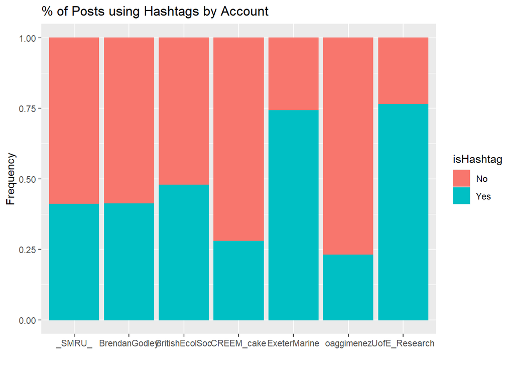

```r
hashtag_df %>%
  mutate(Username = as.factor(Username)) %>%
  arrange(isHashtag, freq) %>%#didnt work
  ggplot(
         aes(y = freq, x = Username, fill = isHashtag, color = isHashtag)) +
    geom_bar(stat = "identity") +
    labs(title = "% of Posts using Hashtags by Account",
         x = "", y = "Frequency")
```

```r
  coord_flip()
```

[output not shown]

Before we consider which #s we **should** use, we consider what hashtags are used the most in our sample?

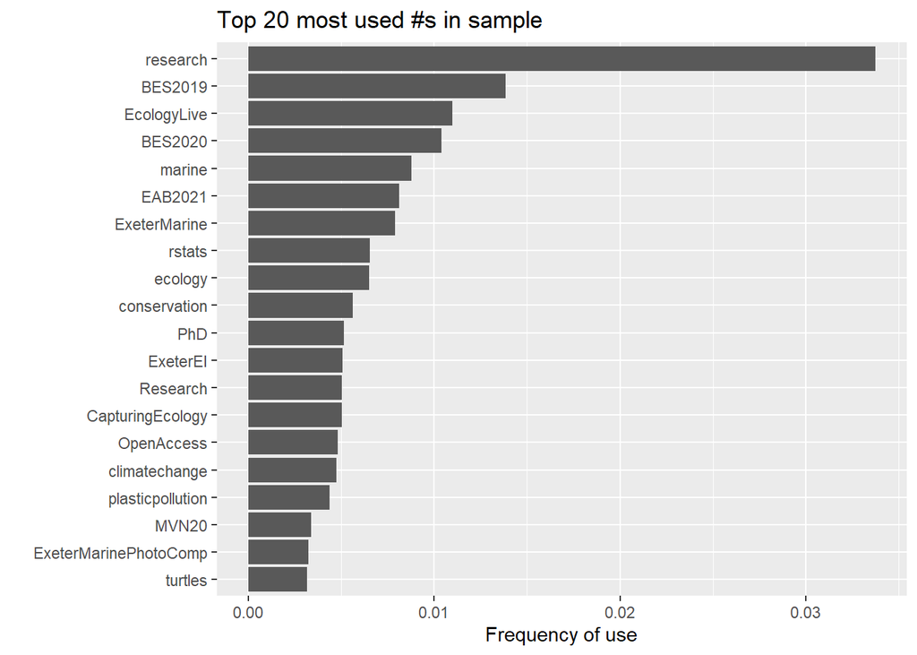

```r
hashtag.likes  <- tweets %>% separate_rows(hashtags) %>%
  group_by(hashtags) %>%
  summarise(meanlikes = mean(likeCount),
            n = n(),
            # freq = n
            score = log(n)*meanlikes) %>%
  mutate(freq = n / sum(n)) %>%
  filter(hashtags != "",n > 10) %>%
  slice_max(freq, n = 20) %>%
              arrange(desc(freq))



p <- ggplot(hashtag.likes,
            aes(x = reorder(hashtags, freq),
            # x =
                y = freq))
p + geom_bar(stat='identity') +
  labs(x = "", y= "Frequency of use",
       title = "Top 20 most used #s in sample")+
  coord_flip()
```

### But, do tweets with hashtags actually perform better?

We combine this analysis with the use of media as well.

```r
media_df <-   tweets %>% group_by(Username, isMedia) %>%
  summarise(avgLikes = mean(likeCount),
            n = n(),
            ) %>%
  mutate(freq = n / sum(n))
```

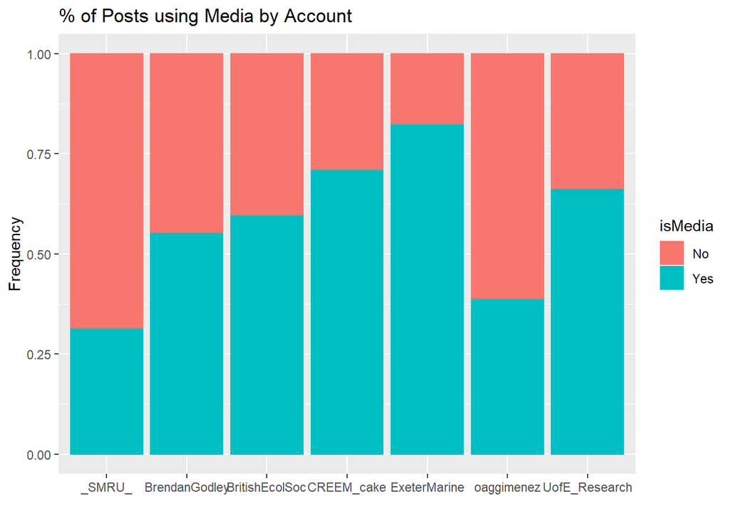

```r
media_df %>%
  ggplot(
         aes(y = freq, x = Username, fill = isMedia, color = isMedia)) +
    geom_bar(stat='identity') +
    labs(title = "% of Posts using Media by Account",
         x = "", y = "Frequency")
```

```r
  coord_flip()
```

[output not shown]

```r
avg.likes.Media <- tweets %>%
  mutate(isMedia = ifelse(isMedia== 'No',
                              'Doesn\'t use media','Uses media')) %>%
  group_by(isHashtag, isMedia) %>%
  summarise(avgLikes = mean(likeCount),
            medianlikes = median(likeCount),
            n = n(),
            )
```

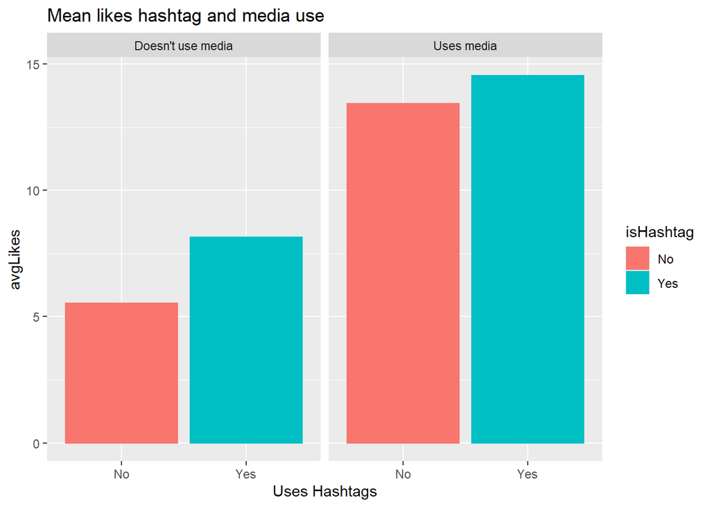

```r
avg.likes.Media %>%  ggplot(aes(
  # x = interaction(isHashtag,isMedia),

  x = isHashtag,
  y = avgLikes,
             fill = isHashtag, color = isHashtag), ) +
  geom_col() +
  facet_grid(cols = vars(isMedia)
  ) +
  labs(title = "Mean likes hashtag and media use",
       x = "Uses Hashtags")
```

```r
# ggplot(data = hashtag_df,
#        aes(y = avgLikes, x = Username, fill = isHashtag, color = isHashtag)) +
#   geom_point() +
#   labs(title = "Mean Likes by Username and # use")
```

```r
avg.likes.Media %>% mutate(avg.increase.likes = ( avgLikes/5.533798 ) - 1#No media/hashtag
                           )
```

| isHashtag | isMedia | avgLikes | medianlikes | n | avg.increase.likes |
| --- | --- | --- | --- | --- | --- |
| No | Doesn't use media | 5.533798 | 2 | 3876 | -4.886008e-08 |
| No | Uses media | 13.425000 | 6 | 3000 | 1.426001e+00 |
| Yes | Doesn't use media | 8.137620 | 4 | 1882 | 4.705306e-01 |
| Yes | Uses media | 14.541029 | 7 | 5423 | 1.627676e+00 |

On average, the use of hashtags correlates with an increase in likes on posts by 47% on posts for without media! For posts with Media but no hashtags it correlates with an increase of 142% ! When you include Media along side a hashtag it correlates with an increase of a staggering 162%.

Breaking this relationship down by username,

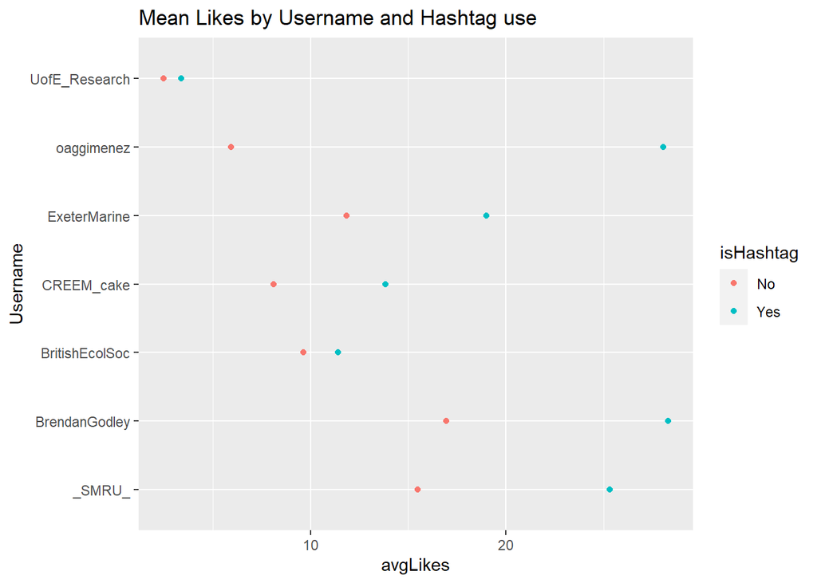

```r
ggplot(data = hashtag_df,
       aes(y = avgLikes, x = Username, fill = isHashtag, color = isHashtag)) +
  geom_point() +
  labs(title = "Mean Likes by Username and Hashtag use")+
  coord_flip()
```

The figure above could indicate that some accounts use hashtags better but this is inconclusive, due to the interaction between the % of hashtag use. i.e UofE_Research posts a lot more posts with #s but has the smallest difference in posts with #s and not.

#### Similarly, we consider media use

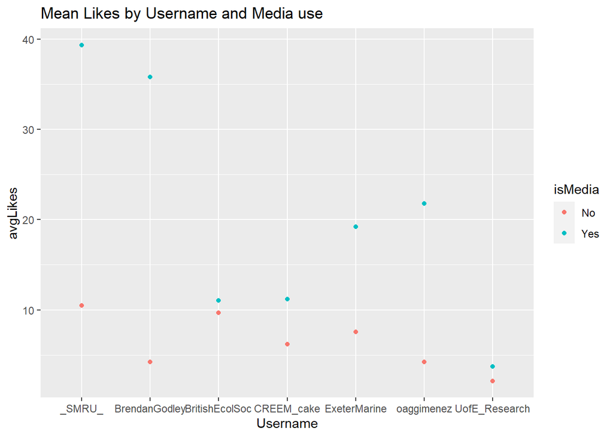

```r
ggplot(data = media_df,
       aes(y = avgLikes, x = Username, fill = isMedia, color = isMedia)) +
  geom_point() +
  labs(title = "Mean Likes by Username and Media use")
```

maybe

Media use performs better across the board.

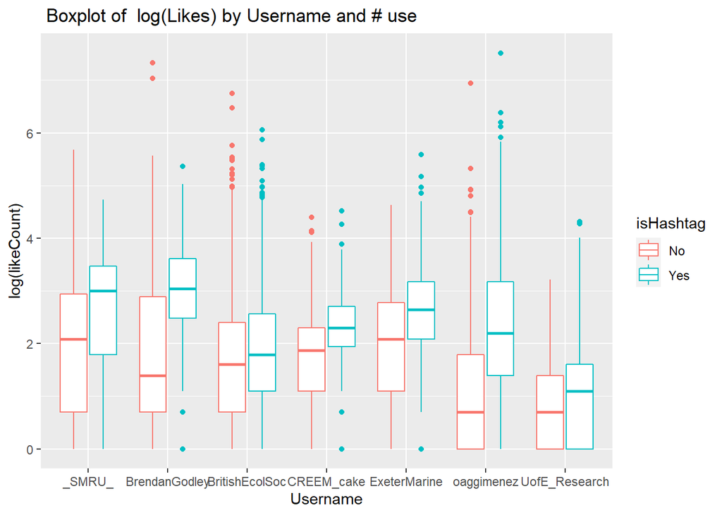

```r
ggplot(data = tweets %>% group_by(Username, isHashtag) %>% filter(likeCount > 0),
       aes(y = log(likeCount), #using log to minimise effect of outliers
           x = Username, color = isHashtag)) +
  geom_boxplot() +
  labs(title = " Boxplot of  log(Likes) by Username and # use ")
```

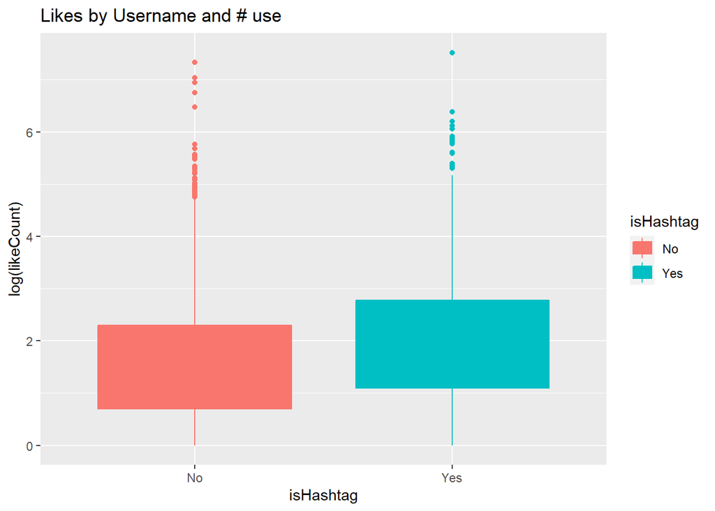

```r
ggplot(data = tweets %>% group_by(isHashtag) %>% filter(likeCount > 0),
       aes(y = log(likeCount), #using log to minimise effect of outliers
           x = isHashtag, fill = isHashtag, color = isHashtag)) +
  geom_boxplot() +
  labs(title = "Likes by Username and # use")
```

Is this significant?

Based on the Distribution of log(likes), we assume it follows a gamma distribution.

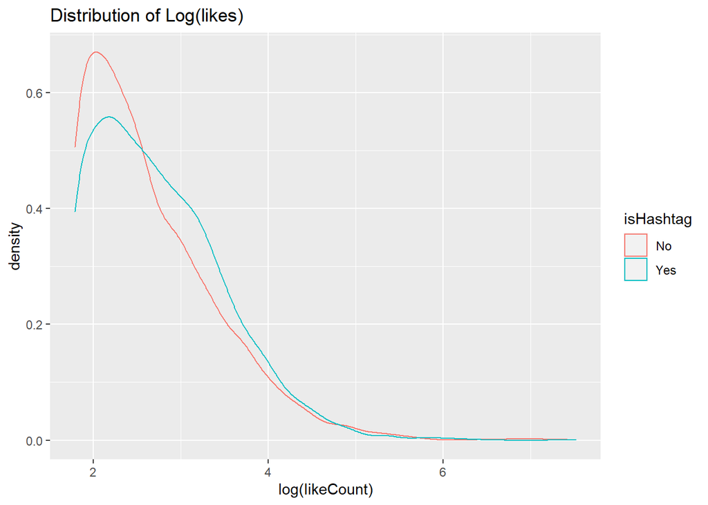

```r
ggplot(data = tweets %>% group_by(isHashtag) %>%
         filter(likeCount > 5), # to remove infrquently used outliers
       aes(x = log(likeCount), #using log to minimise effect of outliers
           # fill = isHashtag,
           color = isHashtag)) +
  # geom_histogram() +
  # geom_freqpoly() +
  geom_density()+
  labs(title = "Distribution of Log(likes)")
```

```r
#plot the distribution of loglike counts?

#%>% group_by(isHashtag) %>% filter(likeCount > 0)
lmfit <- glm(log(likeCount) ~ as.factor(isHashtag)*as.factor(isMedia),
             data = tweets %>% filter(likeCount > 5), family = 'Gamma')

anova(lmfit,test = "Chi")
```

|  | Df | Deviance | Resid. Df | Resid. Dev | Pr(>Chi) |
| --- | --- | --- | --- | --- | --- |
| NULL | NA | NA | 6206 | 432.2583 | NA |
| as.factor(isHashtag) | 1 | 2.42674014 | 6205 | 429.8315 | 1.238922e-08 |
| as.factor(isMedia) | 1 | 4.97504317 | 6204 | 424.8565 | 3.545473e-16 |
| as.factor(isHashtag):as.factor(isMedia) | 1 | 0.05833375 | 6203 | 424.7982 | 3.773169e-01 |

In conclusion, hashtags clearly have an effect.

#### So which ones do we use?

Which hashtags have the biggest effect on likes?

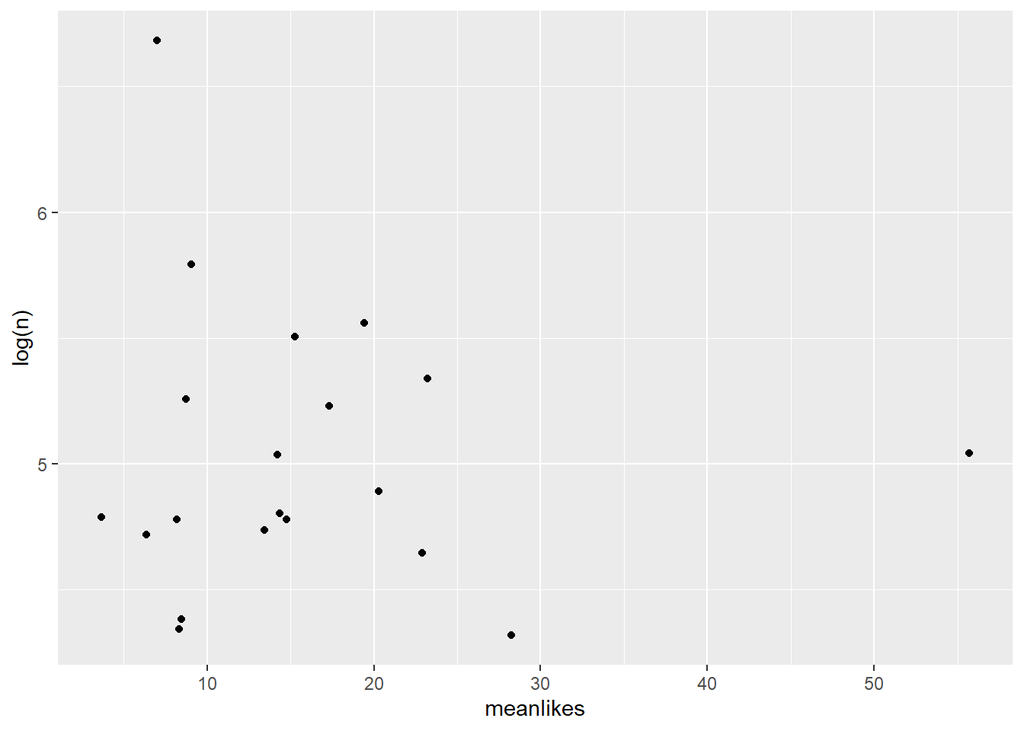

```r
ggplot(hashtag.likes,
       aes(x = meanlikes, y = log(n) )) + geom_point()
```

We clearly need a use penalised measure for this, i.e. we cant use David Attenborough for every post

We define a measure that balances widespread use and effectivity in terms of likes as $log_e(n) * meanLikes$

```r
hashtag.likes %>% slice_max(score,n = 20
                            )
```

| hashtags | meanlikes | n | score | freq |
| --- | --- | --- | --- | --- |
| rstats | 55.690323 | 155 | 280.86997 | 0.006552249 |
| marine | 23.216346 | 208 | 123.91813 | 0.008792695 |
| turtles | 28.253333 | 75 | 121.98343 | 0.003170443 |
| EcologyLive | 19.434615 | 260 | 108.06971 | 0.010990869 |
| plasticpollution | 22.903846 | 104 | 106.37441 | 0.004396348 |
| conservation | 20.308271 | 133 | 99.31453 | 0.005622252 |
| ExeterMarine | 17.347594 | 187 | 90.74715 | 0.007904971 |
| BES2020 | 15.292683 | 246 | 84.19129 | 0.010399053 |
| ecology | 14.207792 | 154 | 71.56398 | 0.006509976 |
| CapturingEcology | 14.747899 | 119 | 70.48203 | 0.005030436 |

[output cut: 10 more lines]

How many hashtags do you need to perform well?

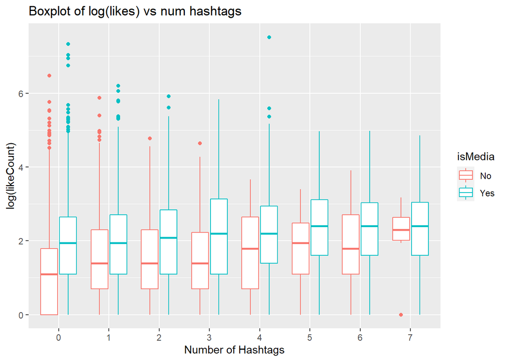

```r
tweets <- tweets %>% mutate(n.hashtags = ifelse(isHashtag=='Yes',
                                                lengths(str_split(hashtags,",")),
                                                0))#return 0 if not hashtags
tweets %>%
  group_by(n.hashtags) %>%
  # summarise(mean_likes = median(likeCount)) %>%
  filter(n.hashtags < 8,
         likeCount > 0 #for log conversion
         ) %>% #

  ggplot(aes(x= as.factor(n.hashtags), y= log(likeCount), color = isMedia)) +
  labs(x = "Number of Hashtags",
       title = "Boxplot of log(likes) vs num hashtags")+
  geom_boxplot()
```

### Whats the best time to tweet?

Time relationship with likes

```r
likes.in.day <- tweets %>% group_by(Username, time_30) %>%
  summarise(avg_likes = mean(likeCount),
            median_likes = median(likeCount),
            n = n())
```

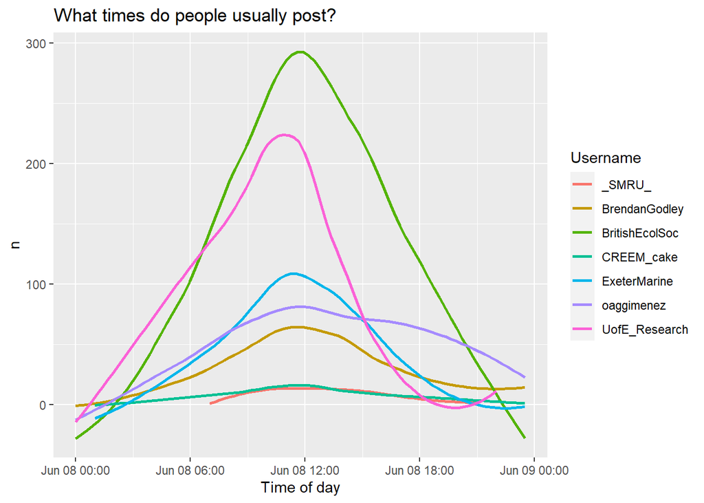

```r
p <- ggplot(data = likes.in.day ,
            aes(x =  as.POSIXct(time_30,format="%H:%M"),
                y = n,
                color = Username, group = Username))
p +
  # geom_point()
  geom_smooth(se = F) +
  # geom_ma(ma_fun = SMA, n= 4) +
  labs(title = "What times do people usually post?",
       x= "Time of day")
```

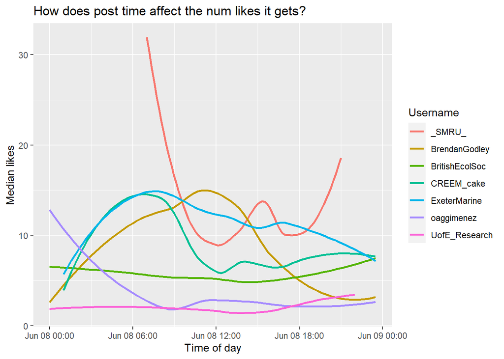

```r
p <- ggplot(data = likes.in.day ,
            aes(x =  as.POSIXct(time_30,format="%H:%M"),
                y = median_likes,
                color = Username, group = Username))
p +
  # geom_point()
  geom_smooth(se = F) +
  # geom_ma(ma_fun = SMA, n= 4) +
  labs(title = "How does post time affect the num likes it gets?",
       y = "Median likes",
       x= "Time of day")
```

No clear sign of what time to post based on our followers. But since all the account are on the same timezone maybe we can aggregate?

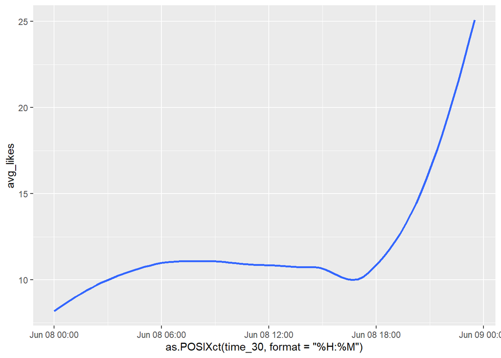

```r
tweets %>% group_by( time_30) %>%
  summarise(avg_likes = mean(likeCount),
            median_likes = median(likeCount),
            n = n()) %>%
  ggplot(aes(x= as.POSIXct(time_30,format="%H:%M"),
             y = avg_likes))+
   geom_smooth(se = F)
```

```r
  # geom_line(aes(y = avg_likes))
```

What if we include day of week?

```r
library(zoo)
library(tidyquant)
```

Num tweets by day?

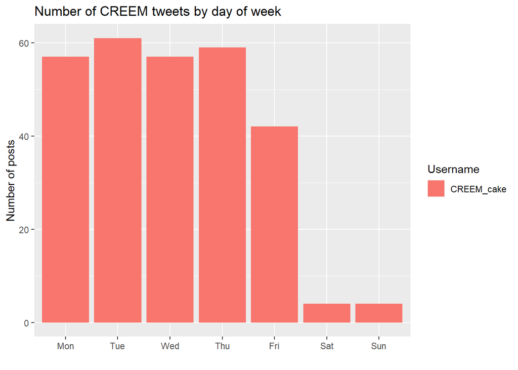

```r
tweets <- tweets %>% mutate(
   day.week = wday(Datetime, week_start=1,label=TRUE
                   ))
tweets%>%
  filter(Username == "CREEM_cake",
         # likeCount < 50  #just to make plot cleaner
         ) %>%

  group_by(Username,day.week) %>%
  summarise(avg_likes = mean(likeCount),
  #           median_likes = median(likeCount),
            n = n()) %>%
  ggplot(aes(
    # x =  as.POSIXct(time_30,format="%H:%M"),
    x = as.factor(day.week),
       y = n,
    fill = Username
       # color = Username,
    # group = Username
         )) +
  # facet_grid(cols = vars(day.week))+
  # geom_line(aes(y=rollmean(median_likes, 3, na.pad=TRUE)))
  geom_col()+
  labs(title = "Number of CREEM tweets by day of week",
       y = "Number of posts",
       x = "")
```

```r
  # geom_histogram(stat= 'identity')
```

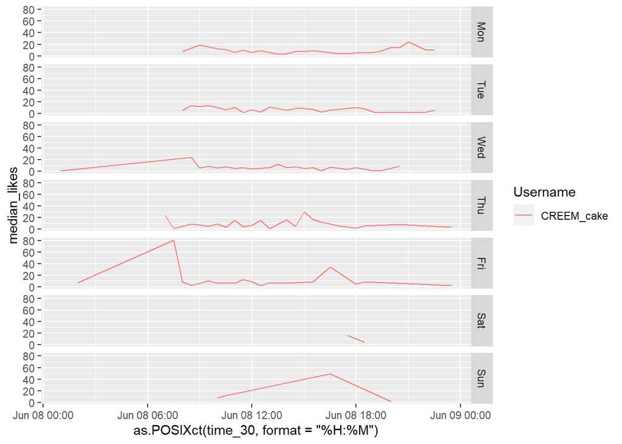

```r
tweets <- tweets %>% mutate(
   day.week = wday(Datetime, week_start=1,label=TRUE
                   ))
tweets%>%
  filter(
  Username == "CREEM_cake",
  # day.week == 'Mon'
  ) %>%
  group_by(Username,day.week, time_30) %>%
  summarise(avg_likes = mean(likeCount),
            median_likes = median(likeCount),
            n = n()) %>%
  ggplot(aes(x =  as.POSIXct(time_30,format="%H:%M"),
         y = median_likes,
         color = Username, group = Username
         )) +
  facet_grid(rows = vars(day.week))+

  # geom_line(aes(y=rollmean(median_likes, 3, na.pad=TRUE)))
  geom_line()
```

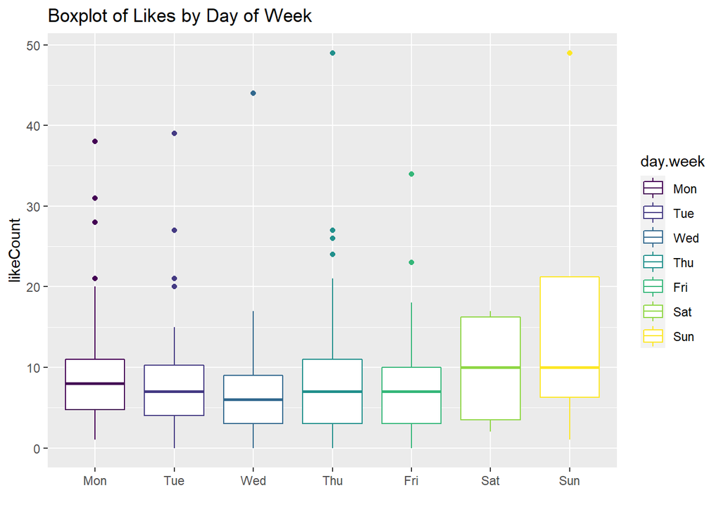

```r
tweets%>%
  filter(Username == "CREEM_cake",
         likeCount < 50  #just to make plot cleaner
         ) %>%


  ggplot(aes(
    # x =  as.POSIXct(time_30,format="%H:%M"),
    x = as.factor(day.week),
       y = likeCount,
       color = day.week,
    # group = Username
         )) +
  # facet_grid(cols = vars(day.week))+
  # geom_line(aes(y=rollmean(median_likes, 3, na.pad=TRUE)))
  geom_boxplot() +
  labs(title = "Boxplot of Likes by Day of Week",
       x = "")
```

```r
tweets%>%
  filter(Username == "CREEM_cake",
         likeCount < 50  #just to make plot cleaner
         ) %>%
   mutate(
    isweekend = ifelse(
      day.week =='Sat'|day.week=='Sun','Yes','No')) %>%
#
  group_by(Username,isweekend) %>%
  summarise(avg_likes = mean(likeCount),
            median_likes = median(likeCount),
            n = n())
```

| Username | isweekend | avg_likes | median_likes | n |
| --- | --- | --- | --- | --- |
| CREEM_cake | No | 8.255556 | 7 | 270 |
| CREEM_cake | Yes | 13.625000 | 10 | 8 |